# Isabella Casanova Python Analysis Project

```python
from IPython.display import display, HTML

display(HTML("""
<div style="position: relative; text-align: center; color: #2c3e50; font-family: Arial;">

  <!-- Top-right logo -->
  <img src="hult_logo.png" alt="Logo of Hult International Business School" width="150"
       style="position: absolute; top: 0; right: 0; margin: 10px;"/>

  <h1 style="font-size: 36px;">Python Analysis Project</h1>

  <p>
    <strong>Student Name:</strong> Isabella Casanova Bastidas<br>
    <strong>Instructor:</strong> Professor Chase Kusterer<br>
    <strong>Course:</strong> Introduction to Python Programming<br>
    <strong>Institution:</strong> Hult International Business School
  </p>

</div>
"""))
```

[figure not shown]

Python Analysis Project

**Student Name:** Isabella Casanova Bastidas  
**Instructor:** Professor Chase Kusterer  
**Course:** Introduction to Python Programming  
**Institution:** Hult International Business School

## 🚲 Bike Rentals Analysis: Bay Wheels

### Introduction

To grow and improve, a company needs to understand how people use its services. Even small things, like the weather or time of day, can change what customers do. By looking at data, businesses can make better decisions and plan more effectively.

Bay Wheels provides bike rentals throughout the city, and this project explores the factors that drive demand. Using data that includes weather, hour, season, and holidays, we aim to discover trends in rental behavior. These findings will help Bay Wheels optimize its operations, like hiring staff, planning schedules, and promoting bikes when demand is highest. The analysis includes visualizations and statistics to clearly explain patterns that are going to be used to collect data to take further decisions. This report shows important patterns in a clear and simple way to help make good business choices.

```python
# importing packages
import pandas as pd             # data science essentials
import matplotlib.pyplot as plt # data visualization essentials
import seaborn as sns           # enhanced data visualization

# suppressing user warnings
import warnings # warnings
warnings.simplefilter(action='ignore', category=UserWarning)


# specifying a file name
file = "bikes_data.xlsx"


# reading the file into Python through pandas
bikes = pd.read_excel (io        = file,
                         sheet_name = 0,
                         header     = 0)

# outputting the first 10 rows of the dataset
print(bikes.head(n=10))
```

```
   ID Month Day of Week  Hour  Temperature  Humidity  Wind Speed  Visibility  \
0   1   Jan      Sunday     0         -3.2        40         0.5        1358
1   2   Jan      Sunday    13          2.4        22         2.3        1921
2   3   Jan      Sunday    16          3.0        28         2.5        1864
3   4   Jan      Sunday    17          1.8        33         3.3        1913
4   5   Jan      Sunday    20         -0.3        40         1.2        1936
5   6   Jan      Monday    10         -1.4        50         1.9        1355
6   7   Jan      Monday    18         -0.8        24         2.3        2000
7   8   Jan     Tuesday    21         -4.3        47         2.8        1997
8   9   Jan   Wednesday     3         -7.4        54         1.7        1968
9  10   Jan   Wednesday     7         -8.1        51         0.5        1987

   Dew Point Temperature  UV Index  Rainfall  Snowfall  Season Holiday  \
0                  -14.9      0.00       0.0       0.0  Winter     Yes
1                  -17.2      1.10       0.0       0.0  Winter     Yes
```

[output cut: 20 more lines]

```python
print(bikes.isnull().sum())  # Checking nulls in columns
```

```
ID                       0
Month                    0
Day of Week              0
Hour                     0
Temperature              0
Humidity                 0
Wind Speed               0
Visibility               0
Dew Point Temperature    0
UV Index                 0
Rainfall                 0
Snowfall                 0
Season                   0
Holiday                  0
RENTALS                  0
dtype: int64
```

```python
print(bikes.describe())     # Checking mean, min, max from the data
```

```
                ID         Hour  Temperature     Humidity   Wind Speed  \
count  1387.000000  1387.000000  1387.000000  1387.000000  1387.000000
mean    694.000000    11.553713    13.093511    58.759193     1.707714
std     400.536723     6.924075    11.902220    20.559202     1.019488
min       1.000000     0.000000   -15.800000    11.000000     0.000000
25%     347.500000     6.000000     3.200000    43.000000     0.900000
50%     694.000000    12.000000    14.100000    58.000000     1.500000
75%    1040.500000    18.000000    22.800000    75.000000     2.300000
max    1387.000000    23.000000    38.000000    98.000000     7.400000

        Visibility  Dew Point Temperature     UV Index     Rainfall  \
count  1387.000000            1387.000000  1387.000000  1387.000000
mean   1434.423216               4.365537     0.573338     0.139005
std     618.087288              13.100902     0.869165     1.262159
min      81.000000             -30.500000     0.000000     0.000000
25%     946.000000              -4.400000     0.000000     0.000000
50%    1718.000000               5.200000     0.010000     0.000000
75%    2000.000000              15.600000     0.975000     0.000000
max    2000.000000              26.600000     3.450000    35.000000

          Snowfall      RENTALS
count  1387.000000  1387.000000
mean      0.079813   810.015862
std       0.444182   694.720990
min       0.000000     5.000000
25%       0.000000   250.500000
50%       0.000000   626.000000
75%       0.000000  1196.500000
max       7.000000  3734.000000
```

### Correlation Heatmap: What Affects Rentals Most?

This heatmap shows how numerical features (like temperature, hour, snowfall) are related to the number of rentals. Darker colors and higher numbers mean a stronger relationship.

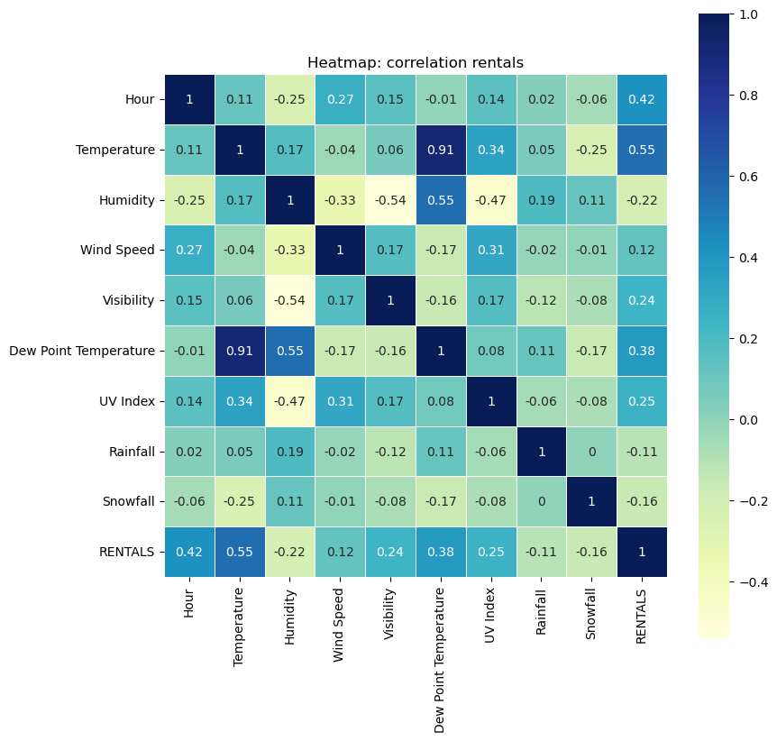

```python
# converting correlation matrix into a DataFrame
correlation_matrix = bikes.iloc[:, 1:].corr(method = 'pearson',
                                      numeric_only = True).round(decimals=2)

# Specifying plot size
fig, ax = plt.subplots(figsize=(9, 9))

# Creating the heatmap
sns.heatmap(data       = correlation_matrix,  # The correlation matrix
            cmap       = 'YlGnBu'          ,  # Cool color scheme
            square     = True              ,  # Square cells
            annot      = True              ,  # Show correlation numbers
            linecolor  = 'white'           ,  # Line color between cells
            linewidths = 0.5               ,) # Line width


# Adding a title
plt.title("Heatmap: correlation rentals")

# Displaying the plot
plt.show()
```

This heatmap shows how different things like temperature, time of day, and weather affect the number of bike rentals. Darker blue means a stronger connection, and lighter colors mean a weaker one.

Looking at the chart, we can see that temperature, hour, and dew point temperature have the strongest positive links to the number of rentals. For example:

- When the temperature goes up, bike rentals usually go up too.
- People rent more bikes at certain hours of the day.

Other things like rain, snow, or humidity don’t seem to have a strong effect. In fact, snow and high humidity are slightly negative, meaning they might lower the number of rentals.

### Insight 1: Weather and Time Matter Most

The strongest influences on rentals are clear in the data. These insights can help Bay Wheels plan operations better:

- Focus on warmer days (especially 20–30°C) for marketing and staffing.
- Prepare for busy hours in the morning and evening, when most rides happen.
- Expect lower demand on rainy, snowy, or humid days and adjust resources accordingly.

These patterns give the company a chance to be more efficient with schedules, staffing, and promotions.

### Rentals by Season: Strip + Box Plot

This combined strip and box plot shows how rentals change throughout the four seasons.

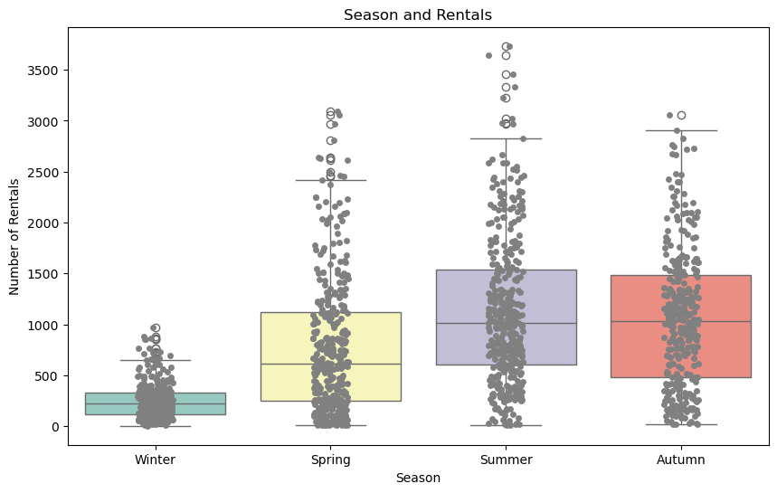

```python
plt.figure(figsize=(10, 6))  # Set plot size

# stripplot for visual clarity (optional)
sns.stripplot(x     ='Season' , # x-axis feature
              y     ='RENTALS', # y-axis feature
              data  = bikes   , # DataFrame where features exist
              color ='gray'   ) # Color

# creating the boxplot
sns.boxplot(x       ='Season' , # x-axis feature
            y       ='RENTALS', # y-axis feature
            hue     ='Season' , # Add hue to match the x variable
            data    = bikes   , # DataFrame where features exist
            palette ='Set3'   ) # Cool colors

# formatting the plot
plt.title(label   ='Season and Rentals')
plt.xlabel(xlabel ='Season'            )
plt.ylabel(ylabel ='Number of Rentals' )
plt.show(block    = True               )
```

The height of the boxes and how the dots are spread tell us how much the rentals go up and down. Bigger boxes and more dots high means more rentals in that season. Smaller boxes and dots close to bottom mean less people renting.

From this graphic, we can see that Winter has the lowest rentals, and Spring, Summer, and Autumn have more, with some days going even over 3,000 rentals.

This graphic shows that Summer has the most rentals overall. During this season, people use bikes a lot, probably because the weather is warm and days are longer.

Spring and Autumn also have a high number of rentals, but not as much as Summer. It’s still good weather for biking, so many people use the service.

On the other hand, Winter has the lowest number of rentals. This could be because it’s cold, and sometimes snowy or rainy, so people prefer not to ride bikes during that time.

This information helps understand when Bay Wheels needs more bikes and workers ready.

### Rentals by Hour and Season

This plot shows when people rent bikes during the day, and how this changes by season.

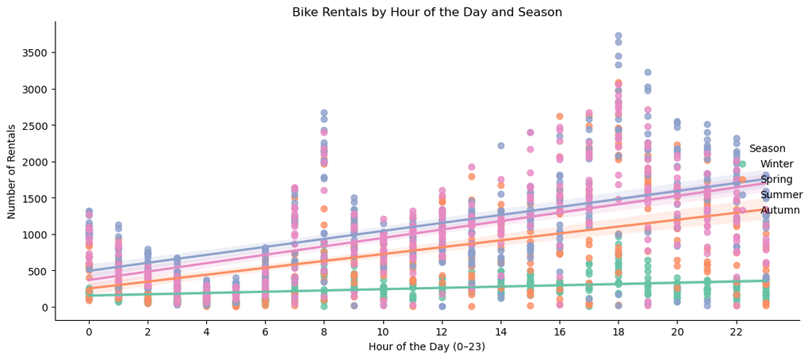

```python
# Define a custom color palette for seasons
custom_palette = {
    "Winter": "#66c2a5",
    "Spring": "#fc8d62",
    "Summer": "#8da0cb",
    "Autumn": "#e78ac3"}

# Plot rentals by hour with trend lines
sns.lmplot(
    x='Hour'    ,           # x-axis feature
    y='RENTALS' ,           # y-axis feature
    hue='Season',           # categorical data for subsets
    data=bikes  ,           # DataFrame where features exist
    palette=custom_palette, # Apply the custom color palette
    scatter=True,           # renders a scatter plot
    fit_reg=True,           # renders a regression line
    aspect=2,               # aspect ratio for plot
)

# formatting and displaying the visualization
plt.title('Bike Rentals by Hour of the Day and Season')       # title
plt.xlabel('Hour of the Day (0–23)')                          # X-axis label
plt.ylabel('Number of Rentals')                               # Y-axis label
plt.xticks(range(0, 24, 2))                                   # Show ticks every 2 hours
plt.tight_layout()                                            # Optimize spacing
plt.show()                                                    # Display the plot
```

This plot shows how bike rentals change during the day for each season. Each dot is a rental count for one hour, and the lines help us see the overall trend. We can see that rentals start low early in the morning and go up as the day goes on, especially during Spring, Summer, and Autumn. Winter stays low most of the time.

There are two big peaks in the day: one around 8 AM and another one between 5 and 6 PM. These are probably the times when people go to work or school and then come back home.

### Insight 3: Commuting Hours Are Key

The data shows that bike rentals go up a lot at 8 AM and again around 5–6 PM. These hours match with the typical times when people go to work or school and then come back home. This trend is much more visible in Spring, Summer, and Autumn, when the weather is better and more people feel comfortable riding a bike.

This suggests that many people use Bay Wheels as a way to commute, especially in warmer seasons. It’s important for the company to make sure there are enough bikes ready during these busy hours, and maybe even offer special passes or promotions for morning and evening users. That way, the company can meet customer needs and improve the service experience during the most active times of the day.

### Temperature Ranges and Rentals

Let’s break down temperatures into ranges and explore how that affects rentals.

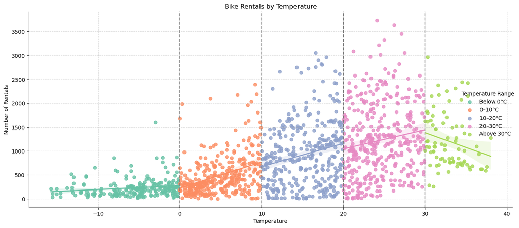

```python
# setting a color palette
sns.set_palette("Set2")


# creating a dummy column in the bikes DataFrame
bikes['Temperature Range'] = ''


# for loop with iterrows()
for index, row in bikes.iterrows():


    # conditionals to change the values in the new column
    if bikes.loc[index, 'Temperature'] < 0:
        bikes.loc[index, 'Temperature Range'] = 'Below 0°C'


    elif bikes.loc[index, 'Temperature'] < 10:
        bikes.loc[index, 'Temperature Range'] = '0–10°C'


    elif bikes.loc[index, 'Temperature'] < 20:
        bikes.loc[index, 'Temperature Range'] = '10–20°C'


    elif bikes.loc[index, 'Temperature'] < 30:
        bikes.loc[index, 'Temperature Range'] = '20–30°C'


    elif bikes.loc[index, 'Temperature'] >= 30:
        bikes.loc[index, 'Temperature Range'] = 'Above 30°C'


    # safety net
    else:
        bikes.loc[index, 'Temperature Range'] = 'error'


# applying a specific order to the temperature categories
temp_order                 = ['Below 0°C', '0–10°C', '10–20°C', '20–30°C', 'Above 30°C']
bikes['Temperature Range'] = pd.Categorical(bikes['Temperature Range'],
categories                 = temp_order,
ordered                    = True)


# instantiating an lmplot for temperature and rentals
sns.lmplot(x          = 'Temperature'       ,
           y          = 'RENTALS'           ,
           hue        = 'Temperature Range' ,  # categorical data for subsets
           scatter    = True                ,
           fit_reg    = True                ,
           aspect     = 2                   ,
           height     = 6                   ,
           data       = bikes               ,
           line_kws   = {'linewidth': 2})


# developing vertical axis lines
value = 0

while value <= 30:

    # making a vertical line
    plt.axvline(x = value, color = "gray", linestyle = '--')

    # incrementing value in 10-degree increments
    value += 10


# formatting and displaying the plot
plt.title       (label  = 'Bike Rentals by Temperature'       )
plt.xlabel      (xlabel = 'Temperature'                       )
plt.ylabel      (ylabel = 'Number of Rentals'                 )
plt.grid        (True   , linestyle = '--', alpha = 0.5       )
plt.tight_layout(pad    = 1.0                                 )
plt.show        (block  = True                                )
```

We can see that when the temperature is below 0°C, there are very few rentals. As the temperature gets warmer, especially between 10°C and 30°C, the number of rentals goes up. The most rentals happen when the temperature is in the 20–30°C range. People probably feel more comfortable riding when it’s warm but not too hot.

However, when the temperature goes above 30°C, rentals start to drop again. This makes sense because biking in very hot weather can be uncomfortable or even unsafe.

### Answers to the Business Questions

#### 3. How should the company strategize?

- Hire more workers for spring, summer, and during commuting hours (8 AM–6 PM).
- Reduce staffing during holidays and winter months when rentals are low.
- Target ads and promotions around good weather forecasts (especially 20–30°C).
- Use flexible staffing for weekends and warmer weekdays.
- Prepare inventory (like available bikes) based on temperature and hour data.

### Extra: Rentals by Day of the Week

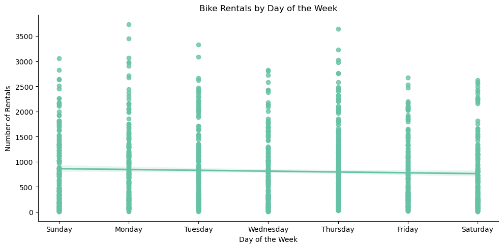

```python
# ordering the days
day_mapping = {'Sunday': 0, 'Monday': 1, 'Tuesday': 2, 'Wednesday': 3,
               'Thursday': 4, 'Friday': 5, 'Saturday': 6}


# Add numeric day column to the DataFrame
bikes['Day Num'] = bikes['Day of Week'].map(day_mapping)


# instantiating a scatter Plot rentals by day number
sns.lmplot(x       = 'Day Num', # x-axis feature
           y       = 'RENTALS', #y-axis feature
           scatter = True     , # renders a scatter plot
           fit_reg = True     , # renders a regression line
           aspect  = 2        , # aspect ratio for plot
           data    = bikes      # categorical data for subsets
          )

# formatting and displaying the plot
plt.title('Bike Rentals by Day of the Week')  # Add title
plt.xlabel('Day of the Week')                 # X-axis label
plt.ylabel('Number of Rentals')               # Y-axis label

# Show actual day names on x-axis
plt.xticks(ticks=list(day_mapping.values()),
          labels=list(day_mapping.keys()))


plt.tight_layout()  # Adjust layout
plt.show()          # Display plot
```

Overall, the number of rentals looks pretty similar during the whole week. There’s no huge change from one day to another, but we can still see a few interesting things. For example, Monday to Thursday seem to have some of the highest peaks, which could mean people are using bikes to go to work or school.

Weekends like Saturday and Sunday also have high rentals, but maybe more for fun or free time activities. The trend line is almost flat, so that tells us the day of the week doesn't strongly change the number of rentals.

Still, knowing this can help Bay Wheels keep service steady every day and be ready for both commuting and weekend riders.

### Conclusion

This analysis helps us understand when and why people rent bikes. We can see that most rentals happen during warm and dry weather, and especially during commuting hours like in the morning and late afternoon. Season and temperature play a big role in rental demand, while cold, rainy, or snowy days reduce interest.

The day of the week doesn’t make a big difference, which means people use bikes pretty evenly all week. But Bay Wheels should still focus on busy times and good weather, because that’s when demand is clearly higher.

With this information, Bay Wheels can make smarter decisions. For example, they can hire more staff and prepare more bikes in spring and summer, and reduce operations during slower, cold days. They can also do promotions on sunny days or target users during rush hours. These actions can help improve service, reduce costs, and increase customer satisfaction.

These findings are also supported by other studies. Gebhart and Noland (2014) found that weather, like temperature and rain, strongly affects bike share trips in Washington, DC. Another study by Faghih-Imani et al. (2014) showed that weather and urban form influence bike flows in Montreal’s BIXI system.

### Sources

Faghih-Imani, A., Eluru, N., El-Geneidy, A. M., Rabbat, M., & Haq, U. (2014). How land-use and urban form impact bicycle flows: Evidence from the bicycle-sharing system (BIXI) in Montreal. Journal of Transport Geography, 41, 306–314. https://doi.org/10.1016/j.jtrangeo.2014.01.013

Gebhart, K., & Noland, R. B. (2014). The impact of weather conditions on bikeshare trips in Washington, DC. Transportation, 41(6), 1205–1225. https://doi.org/10.1007/s11116-014-9540-7